# testing hurdle_cumulative family

Stephen Wild

14/01/2023

## R Markdown

Surveys often contain ordinal variables, like Likert scales. These can be tough to deal with. One great thing about brms is its ability to deal with ordinal data using a cumulative logit (or probit, or cauchit, or…) model, rather than treating the data as continuous.

One issue that often arises is how to model responses when respondents answer “Don’t know.” This happens often. Many times you can only respond to a Likert scale question if you know something about the topic!

In this way, we can treat the responses to the Likert scale as having to overcome a hurdle: You need to know something about the topic to have an opinion on it.

Thankfully, brms let us model this type of data. Let’s start by loading the packages we’ll need.

```r
devtools::load_all("/Users/stephenwild/Desktop/Stats_stuff/brms")
```

```
## ℹ Loading brms
```

```
## Loading 'brms' package (version 2.18.5). Useful instructions
## can be found by typing help('brms'). A more detailed introduction
## to the package is available through vignette('brms_overview').
```

```r
library(tidyverse)
```

To make use our hurdle ordinal model, we’ll create some test data.

```r
# create test data. We'll compare our results to these values
N <- 2500
P <- 5
cutpoints <- c(1, -1)
y <- rep(0, N)
betas <- c(-.15, -.5, 3, .5, -1)
gammas <- c(3, -2, -2, -1, -.5)


# Build predictors and response
set.seed(143140914) # set seed for reproducibility
X <- matrix(runif(N * P), N, P)
p2 <- plogis(cutpoints[1] + X %*% betas)
p3 <- plogis(cutpoints[2] + X %*% betas)


# create thresholds
p1 <- 1 - p2
p2 <- p2 - p3


# sample based on thresholds
for(i in 1:N){
  y[i] <- sample(1:3,
                 size = 1,
                 prob = c(p1[i], p2[i], p3[i]))
}


# Simulate "Don't knows"
# It must be 0 to serve as the hurdle
p <- plogis(X %*% gammas)
dk <- rbinom(N, 1, p)
y[dk == 1] = 0 # replaces "true' values respondents would give if they knew about topic

# put it all together in a dataframe
df <- data.frame(y = y, X)
```

And with that, we have our data. Let’s compare it and see what it looks like.

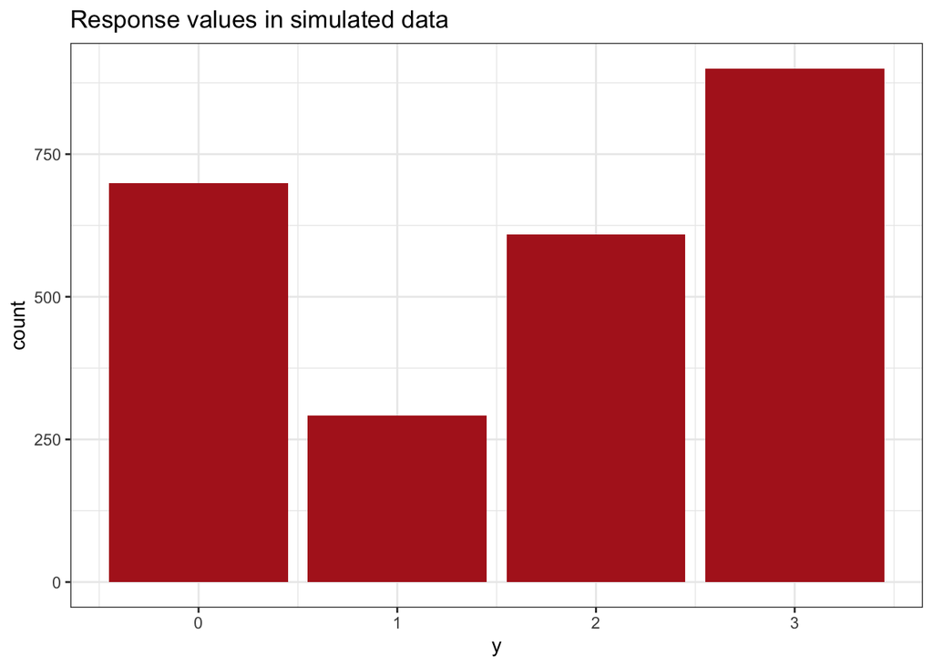

```r
ggplot(data = df) +
  geom_bar(mapping = aes(x = y),
           fill = "firebrick") +
  labs(title = "Response values in simulated data") +
  theme_bw()
```

Perfect. with that we can model our data. We’ll see if the values we get are similar to the parameters we simulated.

```r
mod <- brm(bf(y ~ X1 + X2 + X3 + X4 + X5,
           hu ~ 0 + X1 + X2 + X3 + X4 + X5),
           family = hurdle_cumulative(),
           data = df,
           cores = 4,
           chains = 4)
```

```
## Trying to compile a simple C file
```

```r
mod
```

```
##  Family: hurdle_cumulative
##   Links: mu = logit; hu = logit; disc = identity
## Formula: y ~ X1 + X2 + X3 + X4 + X5
##          hu ~ 0 + X1 + X2 + X3 + X4 + X5
##    Data: df (Number of observations: 2500)
##   Draws: 4 chains, each with iter = 2000; warmup = 1000; thin = 1;
##          total post-warmup draws = 4000
##
## Population-Level Effects:
##              Estimate Est.Error l-95% CI u-95% CI Rhat Bulk_ESS Tail_ESS
## Intercept[1]    -0.65      0.19    -1.04    -0.28 1.00     7962     2929
## Intercept[2]     1.29      0.19     0.93     1.66 1.00     7456     2818
## X1              -0.17      0.17    -0.50     0.17 1.00     6053     2751
## X2              -0.28      0.17    -0.60     0.05 1.00     6130     2906
## X3               3.16      0.18     2.81     3.53 1.00     5081     2690
## X4               0.64      0.17     0.31     0.96 1.00     7822     3144
## X5              -1.03      0.17    -1.36    -0.68 1.00     6071     2613
## hu_X1            3.27      0.19     2.92     3.64 1.00     4110     2716
## hu_X2           -2.08      0.17    -2.41    -1.77 1.00     5504     3152
## hu_X3           -1.95      0.17    -2.28    -1.63 1.00     5662     3356
## hu_X4           -1.30      0.17    -1.63    -0.98 1.00     5674     2833
## hu_X5           -0.47      0.16    -0.77    -0.16 1.00     6205     3206
##
## Family Specific Parameters:
##      Estimate Est.Error l-95% CI u-95% CI Rhat Bulk_ESS Tail_ESS
## disc     1.00      0.00     1.00     1.00   NA       NA       NA
##
## Draws were sampled using sampling(NUTS). For each parameter, Bulk_ESS
## and Tail_ESS are effective sample size measures, and Rhat is the potential
## scale reduction factor on split chains (at convergence, Rhat = 1).
```

Success! our values are similar. That’s good and what we want to see. Let’s also try other links to make sure they work too.

```r
mod2 <- brm(bf(y ~ X1 + X2 + X3 + X4 + X5,
              hu ~ 0 + X1 + X2 + X3 + X4 + X5),
           family = hurdle_cumulative(link = "probit"),
           data = df,
           cores = 4,
           chains = 4)
```

```
## Trying to compile a simple C file
```

```r
mod3 <- brm(bf(y ~ X1 + X2 + X3 + X4 + X5,
               hu ~ 0 + X1 + X2 + X3 + X4 + X5),
            family = hurdle_cumulative(link = "cauchit"),
            data = df,
            cores = 4,
            chains = 4)
```

```
## Trying to compile a simple C file
```

```r
mod2
```

```
##  Family: hurdle_cumulative
##   Links: mu = probit; hu = logit; disc = identity
## Formula: y ~ X1 + X2 + X3 + X4 + X5
##          hu ~ 0 + X1 + X2 + X3 + X4 + X5
##    Data: df (Number of observations: 2500)
##   Draws: 4 chains, each with iter = 2000; warmup = 1000; thin = 1;
##          total post-warmup draws = 4000
##
## Population-Level Effects:
##              Estimate Est.Error l-95% CI u-95% CI Rhat Bulk_ESS Tail_ESS
## Intercept[1]    -0.38      0.12    -0.60    -0.15 1.00     7465     2945
## Intercept[2]     0.76      0.12     0.54     0.99 1.00     7866     3053
## X1              -0.13      0.10    -0.33     0.07 1.00     7060     2869
## X2              -0.16      0.10    -0.36     0.03 1.00     7508     3012
## X3               1.87      0.11     1.66     2.08 1.00     6246     2957
## X4               0.37      0.10     0.18     0.57 1.00     7292     2571
## X5              -0.57      0.10    -0.76    -0.39 1.00     6567     2898
## hu_X1            3.27      0.19     2.91     3.65 1.00     5045     3155
## hu_X2           -2.08      0.17    -2.42    -1.75 1.00     7150     2780
## hu_X3           -1.95      0.17    -2.27    -1.63 1.00     5542     2598
## hu_X4           -1.30      0.17    -1.64    -0.98 1.00     5631     2853
## hu_X5           -0.47      0.16    -0.78    -0.15 1.00     6529     3002
##
## Family Specific Parameters:
##      Estimate Est.Error l-95% CI u-95% CI Rhat Bulk_ESS Tail_ESS
## disc     1.00      0.00     1.00     1.00   NA       NA       NA
##
## Draws were sampled using sampling(NUTS). For each parameter, Bulk_ESS
## and Tail_ESS are effective sample size measures, and Rhat is the potential
## scale reduction factor on split chains (at convergence, Rhat = 1).
```

```r
mod3
```

```
##  Family: hurdle_cumulative
##   Links: mu = cauchit; hu = logit; disc = identity
## Formula: y ~ X1 + X2 + X3 + X4 + X5
##          hu ~ 0 + X1 + X2 + X3 + X4 + X5
##    Data: df (Number of observations: 2500)
##   Draws: 4 chains, each with iter = 2000; warmup = 1000; thin = 1;
##          total post-warmup draws = 4000
##
## Population-Level Effects:
##              Estimate Est.Error l-95% CI u-95% CI Rhat Bulk_ESS Tail_ESS
## Intercept[1]    -0.77      0.20    -1.16    -0.39 1.00     6677     2589
## Intercept[2]     1.30      0.20     0.91     1.69 1.00     6488     2965
## X1              -0.01      0.17    -0.35     0.32 1.00     6545     2711
## X2              -0.30      0.17    -0.62     0.03 1.00     6369     3091
## X3               2.97      0.21     2.56     3.39 1.00     3469     3223
## X4               0.64      0.17     0.32     0.96 1.00     5548     3356
## X5              -1.14      0.17    -1.48    -0.80 1.00     5043     3031
## hu_X1            3.27      0.19     2.92     3.64 1.00     4626     3277
## hu_X2           -2.08      0.18    -2.43    -1.73 1.00     5406     3065
## hu_X3           -1.95      0.16    -2.26    -1.63 1.00     5984     2955
## hu_X4           -1.30      0.16    -1.62    -0.99 1.00     5604     2595
## hu_X5           -0.47      0.16    -0.78    -0.15 1.00     5589     2942
##
## Family Specific Parameters:
##      Estimate Est.Error l-95% CI u-95% CI Rhat Bulk_ESS Tail_ESS
## disc     1.00      0.00     1.00     1.00   NA       NA       NA
##
## Draws were sampled using sampling(NUTS). For each parameter, Bulk_ESS
## and Tail_ESS are effective sample size measures, and Rhat is the potential
## scale reduction factor on split chains (at convergence, Rhat = 1).
```

Finally, we want to test the post-processing functions, like `loo_compare()` and `pp_check()`. This is important, because a lot of users use brms because a) Stan can be confusing, and b) it’s easy to work with brmsfit objects.

```r
loo_compare.brmsfit(add_criterion(mod, criterion = "loo"),
                    add_criterion(mod2, criterion = "loo"),
                    add_criterion(mod3, criterion = "loo"))
```

```
##                                        elpd_diff se_diff
## add_criterion(mod, criterion = "loo")    0.0       0.0
## add_criterion(mod2, criterion = "loo")  -1.2       1.8
## add_criterion(mod3, criterion = "loo") -22.2       6.2
```

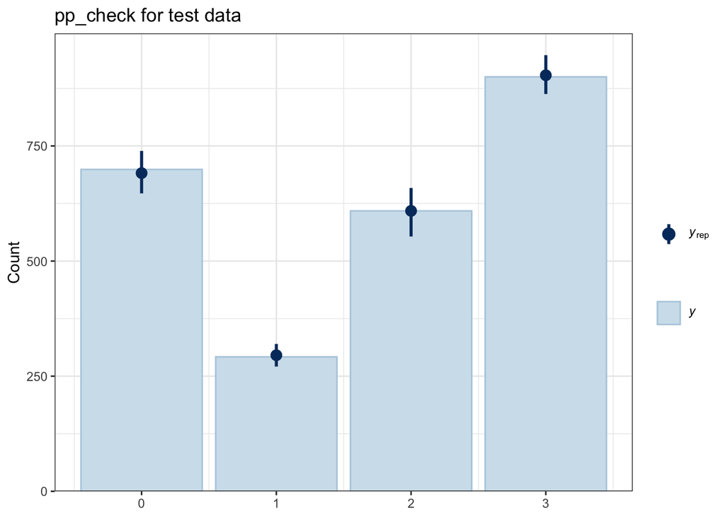

```r
pp_check(mod, type = "bars", ndraws = 50) +
  labs(title = "pp_check for test data") +
  theme_bw()
```

## test with merkel data used by Octavio Medina

Finally, we want to test it on real data. Thankfully, Octavio Medina has us covered. He has a great [blog post](https://octavio.me/posts/dont-knows/) on using Stan to model “Don’t knows.” He also produced a [custom brms family](https://discourse.mc-stan.org/t/modeling-non-response-in-ordinal-survey-data/25151/2) that can be used.

I’m going to skip a lot of what he did with Stan and the custom family and simply load his data.

```r
merkel <- read.csv("https://raw.githubusercontent.com/octmedina/zi-ordinal/main/merkel_data.csv")

mod_merkel <- brm(bf(confid_merkel ~ edu + race + income + party,
                     #disc ~ 1 + edu,
                     hu ~ 1 + edu + race + income + party),
                  data = merkel,
                  family = hurdle_cumulative(),
                  cores = 4,
                  chains = 4)
```

```
## Trying to compile a simple C file
```

```r
mod_merkel
```

```
##  Family: hurdle_cumulative
##   Links: mu = logit; hu = logit; disc = identity
## Formula: confid_merkel ~ edu + race + income + party
##          hu ~ 1 + edu + race + income + party
##    Data: merkel (Number of observations: 811)
##   Draws: 4 chains, each with iter = 2000; warmup = 1000; thin = 1;
##          total post-warmup draws = 4000
##
## Population-Level Effects:
##              Estimate Est.Error l-95% CI u-95% CI Rhat Bulk_ESS Tail_ESS
## Intercept[1]    -2.67      0.17    -3.02    -2.34 1.00     3547     2941
## Intercept[2]    -0.15      0.13    -0.41     0.10 1.00     5853     3807
## Intercept[3]     0.83      0.14     0.56     1.09 1.00     6187     3512
## hu_Intercept    -2.18      0.24    -2.65    -1.74 1.00     8254     2785
## edu             -0.69      0.16    -1.01    -0.38 1.00     4192     3058
## race             0.70      0.20     0.29     1.11 1.00     5227     2836
## income          -0.02      0.15    -0.31     0.28 1.00     4789     3493
## party           -1.63      0.16    -1.96    -1.32 1.00     4229     3263
## hu_edu          -0.67      0.34    -1.36    -0.02 1.00     4289     2853
## hu_race          0.68      0.35    -0.01     1.38 1.00     5419     2950
## hu_income       -0.39      0.32    -1.02     0.23 1.00     4889     3452
## hu_party        -0.28      0.31    -0.89     0.33 1.00     4932     2985
##
## Family Specific Parameters:
##      Estimate Est.Error l-95% CI u-95% CI Rhat Bulk_ESS Tail_ESS
## disc     1.00      0.00     1.00     1.00   NA       NA       NA
##
## Draws were sampled using sampling(NUTS). For each parameter, Bulk_ESS
## and Tail_ESS are effective sample size measures, and Rhat is the potential
## scale reduction factor on split chains (at convergence, Rhat = 1).
```

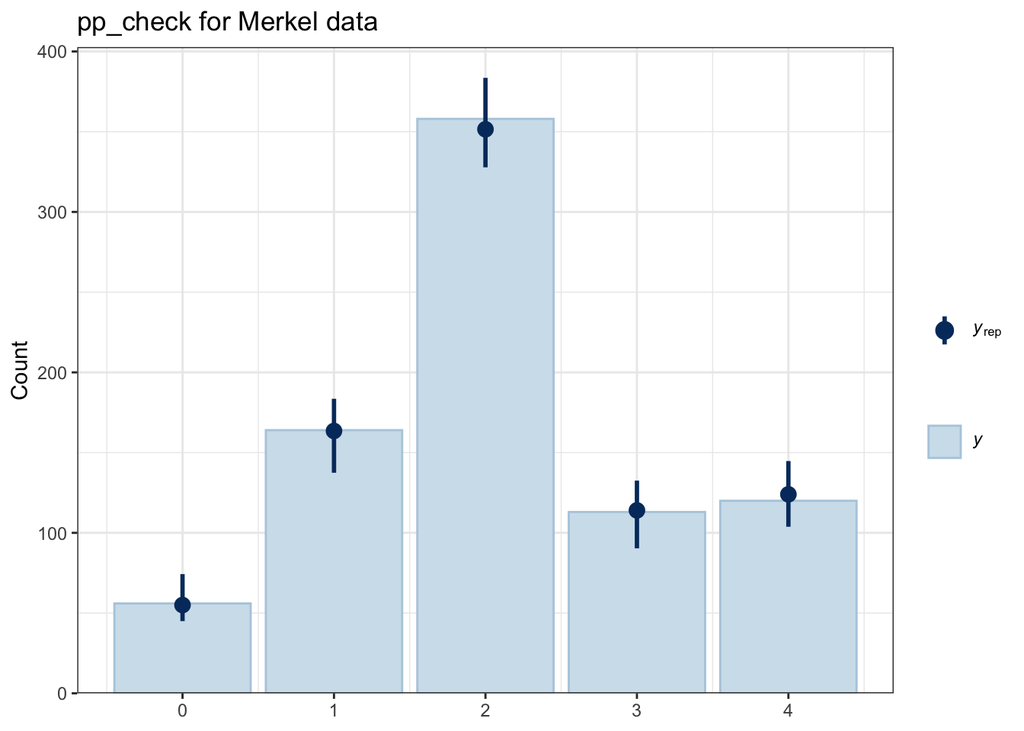

```r
pp_check(mod_merkel, type ="bars", ndraws = 50) +
  labs(title = "pp_check for Merkel data") +
  theme_bw()
```

And there is is. The hurdle_cumulative family works.